# Methods & Results Section

```r
suppressPackageStartupMessages(
  {
    library(tidyverse, quietly = TRUE)
    library(knitr, quietly = TRUE)
    library(DAAG, quietly = TRUE)
    library(here, quietly = TRUE)
    library(naniar, quietly = TRUE)
    library(kableExtra, quietly = TRUE)
    library(ggsignif, quietly = TRUE)
    library(viridis, quietly = TRUE)
    library(forcats, quietly = TRUE)
    library(caret, quietly = TRUE)
    library(ROSE, quietly = TRUE)
    library(e1071, quietly = TRUE)
    library(ModelMetrics, quietly = TRUE)
    library(scales, quietly = TRUE)
    library(ggcorrplot, quietly = TRUE)
  }
)
### This function is used to format a p value and return an APA valid string with threshold of 0.05
p_format <- function(vec, thresh = 0.05, star1 = 0.05, star2 = 0.01, star3 = 0.001){

  vec2 = NULL
  vec2 <- sapply(vec, formatC)

  for(x in 1:length(vec)){
    if(vec[x] <= star3){
      vec2[x] = "< 0.001 ***"
    }
    else if(vec[x] <= star2){
      vec2[x] = "< 0.01 **"
    }
    else if(vec[x] <= star1){
      vec2[x] = "< 0.05 *"
    }
  }
  vec2
}

### This function is used to plot the results of the permutation-t tests
### It uses the ggsignif package to add bridges between groups and p values
permutation_plot <- function(df, height = 1.2, tip = 0.1){

  n <- df %>%
    rowid_to_column() %>%
    group_by(variable) %>%
    arrange(-Mean) %>%
    slice(1) %>%
    pull(rowid)
  y_position <- df$Mean[n] * height

  plt  <- df %>%
    mutate(Feature = variable) %>%
    {
      ggplot(., aes(x = Feature, y = Mean, fill = Group)) +
        geom_col(position = "dodge") +
        theme_minimal() +
        theme(axis.text.x = element_text(angle = 90, hjust = 1), text = element_text(size=17, family = "Times")) +
        geom_signif(family = "Times", annotations = sapply(.$p.val[n], p_format),
                    xmin = seq(0.8, length.out = length(n)),
                    xmax = seq(1.2, length.out = length(n)),
                    y_position = y_position,
                    tip_length=tip
                    ) +
        scale_fill_viridis_d(labels = c("Control", "Episode"))
  }
  plt
}

set.seed(1342)
```

```r
# all initial surveys
all_surveys <- read_csv(here('data','Preprocessing_data_outputs', 'UpdatedSurveys_180713.csv')) %>%
  filter(complete.cases(.)) %>%
  mutate(Y = ifelse(EmotionalEatingEpisodes == 2, 'Control', 'Episode'))

# data used for frequency domain analysis
df_freq <- read_csv(here('data', 'Preprocessing_data_outputs', 'Paper', 'data_out_20181113.csv'))

# data used for time domain analysis
df_time <- read_csv(here('data', 'Preprocessing_data_outputs', 'Paper', 'data_out.csv'))
```

## Statistical Analyses

Data analyses were carried out in R version 3.5.0 (2018-04-23) and Python 2.7. In accordance with previous studies examining the relation between HRV and discrete eating episodes (Friesen et al. 2007; Harthoorn and Dransfield 2007; Ranzenhofer et al. 2016), physiological data collected in the 30-minute period preceding the eating episode were examined. For each participant, the inter-beat interval (IBI) for each self-reported survey was selected, where surveys were either self-reported at the time of an eating episode, or pseudo-randomly triggered in the app. This resulted in an initial total of $n=$ 487 emotional eating episodes and $n=$ 3155 control episodes before cleaning the data.

Using the RHRV package (Rodriguez-Linares et al. 2017), IBI data streams were filtered, interpolated, and artifacts were removed, using thresholds and parameters in compliance with normative reported values for heart rate variability features (Shaffer and Ginsberg 2017). Observations that did not meet normative criteria were removed. Consistent with existing research, features of heart rate variability were extracted from both the time and frequency domain to measure both the amount of variability and the amount of signal energy in the 30-minute period (Shaffer and Ginsberg 2017; Rubin et al. 2016).

The following heart rate variability features were extracted from the IBI streams for each observation in the time domain: *SDNN* (Standard Deviation of all filtered inter-beat intervals); *SDANN* (Standard Deviation of inter-beat intervals between all successive heartbeats); *SDNNIX* (Mean of the standard deviations of all the filtered inter-beat intervals for each 5 min segment of the IBI stream); *pNN50* (Percentage of successive inter-beat intervals that differ by more than 50 ms); *SDSD* (Standard Deviation of Successive Differences of inter-beat intervals); *rMSSD* (Root Mean Square of Successive Differences); *IRRR* (length of the interval determined by the first and the third quantile of the inter-beat interval); *MADRR* (Median of the Absolute values of the successive Differences between the inter-beat intervals); *TINN* (Triangular Interpolation of inter-beat interval histogram); and *HRVi* (Heart Rate Variability index) (Rodriguez-Linares et al. 2017). *SDNN* reflects the power of the components responsible for variability in heart rhythm, while *SDANN*, *SDNNIX*, *pNN50*, *SDSD*, *rMSSD*, *IRRR*, and *MADRR* reflect different statistical aspects of the high frequency variation in heart rhythm. Finally, *TINN* and *HRVi* represent geometric measures calculated from the density distribution of inter-beat intervals (Rodriguez-Linares et al. 2017).

In the frequency domain, features extracted included the mean non-interpolated heart rate (*mean niHR*), the mean interpolated Heart Rate (*mean HR*), and the heart rate values at the start and end of the 30 minute window (*Start HR*, *End HR*). Additional frequency domain features were extracted from the 30 minute streams by applying a Fourier transform to the heart rate signal, resulting in a spectrogram of the heart rate in the low and high frequency ranges. To extract a sufficient amount of information from these spectograms and increase the variance of our data, the spectrogram was split into 5 minute windows, as has been done previously in studies using heart rate variability to predict event-level behavior (Rubin et al. 2016). Mean features were extracted from each of these windows — the mean Low Frequency signal ($LF_1$, $LF_2$,… $LF_6$), the mean High Frequency signal ($HF_1$, $HF_2$,… $HF_6$), and the mean Low Frequency-High Frequency Ratio ($LFHF_1$, $LFHF_2$,… $LFHF_6$).

In order to examine any differences between means of the features, and address the issue of group imbalance affecting statistical power, we conducted between-groups permutation T-tests with each variable in the time and frequency domain (Maindonald and Braun 2015; Good 2013). Then, using the CARET package (Jed Wing et al. 2018), a Support Vector Machine with a polynomial kernel was implemented to predict episodes from controls. In order to address the group imbalance in this stage, all features were standardized, while controls were randomly downsampled and episodes were randomly upsampled using the ROSE package (Lunardon, Menardi, and Torelli 2014). To evaluate model performance, models were tested using 4-fold cross validation, training models on 3/4 of the data and using the remaining data evaluate the model accuracy, specificity, and sensitivity.

# Results

## Missingness.

```r
df_time_nrow <- df_time %>%
  # use params threshold = 250, windows = 2
  filter(threshold == 250 & winds == 2) %>%
  # remove high stress controls
  filter(!(Stress >= 5 & Y == "Control")) %>%
  select(-c(winds, threshold, index, when, Event, Stress, ID), Y, SDNN:HRVi) %>%
  group_by(Y) %>%
  count()

df_freq_nrow <- df_freq %>%
  # use params threshold = 100, windows = 2
  filter(threshold == 100 & winds == 2) %>%
  # remove high stress controls
  filter(!(Stress >= 5 & Y == "Control")) %>%
  select(-c(winds, threshold, index, when, Event, Stress, ID), Y, SDNN:HRVi) %>%
  group_by(Y) %>%
  count()
```

(ref:missingness-time) Completeness of Features in the Time Domain

(ref:missingness-freq) Completeness of Features in the Frequency Domain

(ref:missingness-tab) Number of Observations Extracted for Each Feature

After cleaning the dataset of erroneous surveys (e.g. no usable IBI data; overlapping survey responses; control observations with high self-reported stress), and filtering IBI streams that did not meet filtering quality criteria for preprocessing, the data consisted of $n=$ 285 emotional eating episodes and $n=$ 1753 controls. Of these clean observations, HRV features were extracted from the IBI streams, although even with filtering, many IBI streams were too sparse to compute HRV features. Figures @ref(fig:missingness-time) and @ref(fig:missingness-freq) illustrate the completeness of data in the extracted time and frequency domain features, with table @ref(tab:missingness-tab) showing the final number of observations used for analysis. Much of the data missing from the time domain is due to the fact that these features are derived from SDNN and are dependent on having sufficient data in this feature.

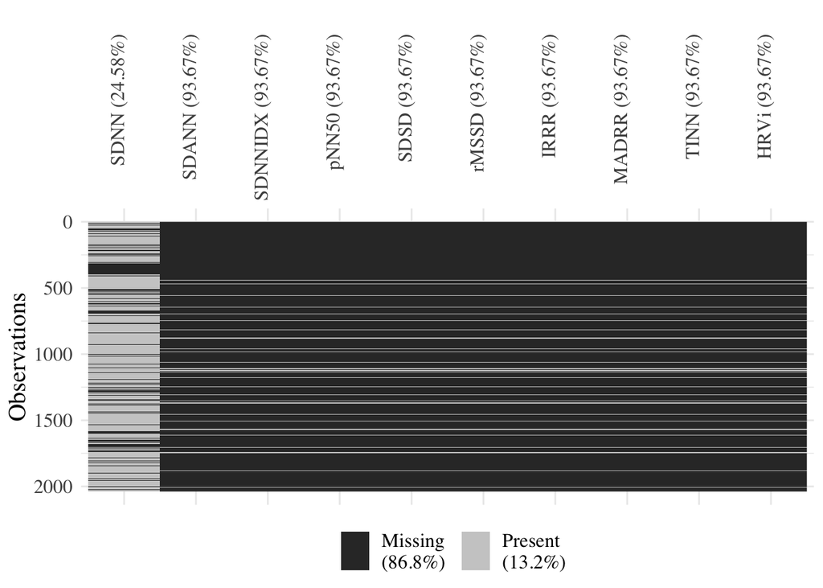

(ref:missingness-time)

```r
df_time %>%
  # use params threshold = 250, windows = 2
  filter(threshold == 250 & winds == 2) %>%
  # remove high stress controls
  filter(!(Stress >= 5 & Y == "Control")) %>%
  select(-c(winds, threshold, index, when, Event, Stress, ID, Y), SDNN:HRVi) %>%
  vis_miss(.) +
  theme(
    axis.text.x = element_text(angle = 90, hjust = 1),
    text = element_text(size=15, family = "Times")
    )
```

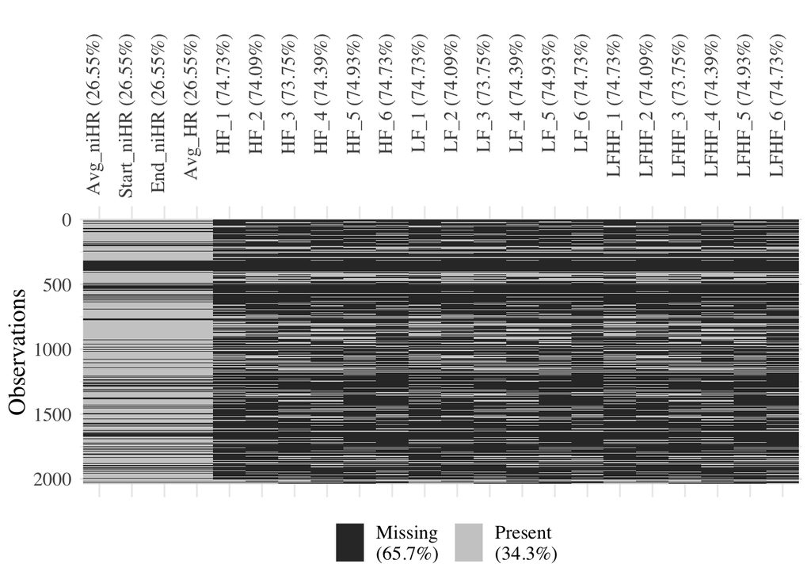

(ref:missingness-freq)

```r
df_freq %>%
  # use params threshold = 100, windows = 2
  filter(threshold == 100 & winds == 2) %>%
  # remove high stress controls
  filter(!(Stress >= 5 & Y == "Control")) %>%
  select(-c(winds, threshold, index, when, Event, Stress, ID, Y)) %>%
  select(Avg_niHR:LFHF_6) %>%
  vis_miss(.) +
  theme(
    axis.text.x = element_text(angle = 90, hjust = 1),
    text = element_text(size=15, family = "Times")
    )
```

```r
### Below, gather the NA in frequency and time domain and tabulate

missingnesstable_time <- df_time %>%
  # use params threshold = 250, windows = 2
  filter(threshold == 250 & winds == 2) %>%
  # remove high stress controls
  filter(!(Stress >= 5 & Y == "Control")) %>%
  select(-c(winds, threshold, index, when, Event, Stress, ID), Y, SDNN:HRVi) %>%
  group_by(Y) %>%
  summarise_all(funs(sum(!is.na(.)))) %>%
  t()

colnames(missingnesstable_time) <- missingnesstable_time[1,]
missingnesstable_time <- missingnesstable_time[-1,] %>%
  data.frame() %>%
  rownames_to_column(var = "Variable")

missingnesstable_freq <- df_freq %>%
  # use params threshold = 250, windows = 2
  filter(threshold == 100 & winds == 2) %>%
  # remove high stress controls
  filter(!(Stress >= 5 & Y == "Control")) %>%
  # select frequency domain
  select(-c(winds, threshold, index, when, Event, Stress, ID)) %>%
  select(Y, Avg_niHR:LFHF_6) %>%
  group_by(Y) %>%
  summarise_all(funs(sum(!is.na(.)))) %>%
  t()

colnames(missingnesstable_freq) <- missingnesstable_freq[1,]
missingnesstable_freq <- missingnesstable_freq[-1,] %>%
  data.frame() %>%
  rownames_to_column(var = "Variable")

bind_rows(missingnesstable_time, missingnesstable_freq)%>%
  kable(caption = '(ref:missingness-tab)') %>%
  kable_styling() %>%
  kableExtra::group_rows("Heart Rate Variability", 1, 10) %>%
  kableExtra::group_rows("Heart Rate", 11, 14) %>%
  kableExtra::group_rows("High Frequency", 15, 20) %>%
  kableExtra::group_rows("Low Frequency", 21, 26) %>%
  kableExtra::group_rows("LF-HF Ratio", 27, 32)
```

(ref:missingness-tab)

| Variable | Control | Episode |
| --- | --- | --- |
| **Heart Rate Variability** |  |  |
| SDNN | 1318 | 219 |
| SDANN | 110 | 19 |
| SDNNIDX | 110 | 19 |
| pNN50 | 110 | 19 |
| SDSD | 110 | 19 |
| rMSSD | 110 | 19 |
| IRRR | 110 | 19 |
| MADRR | 110 | 19 |
| TINN | 110 | 19 |
| HRVi | 110 | 19 |
| **Heart Rate** |  |  |
| Avg_niHR | 1282 | 215 |
| Start_niHR | 1282 | 215 |
| End_niHR | 1282 | 215 |
| Avg_HR | 1282 | 215 |
| **High Frequency** |  |  |
| HF_1 | 433 | 82 |
| HF_2 | 451 | 77 |
| HF_3 | 456 | 79 |
| HF_4 | 440 | 82 |
| HF_5 | 445 | 66 |
| HF_6 | 444 | 71 |
| **Low Frequency** |  |  |
| LF_1 | 433 | 82 |
| LF_2 | 451 | 77 |
| LF_3 | 456 | 79 |
| LF_4 | 440 | 82 |
| LF_5 | 445 | 66 |
| LF_6 | 444 | 71 |
| **LF-HF Ratio** |  |  |
| LFHF_1 | 433 | 82 |
| LFHF_2 | 451 | 77 |
| LFHF_3 | 456 | 79 |
| LFHF_4 | 440 | 82 |
| LFHF_5 | 445 | 66 |
| LFHF_6 | 444 | 71 |

## Comparison using Episodes and Controls using t-tests.

```r
### Run Permutation T-tests

df_time_summaries <- df_time %>%
  # use params threshold = 250, windows = 2
  filter(threshold == 250 & winds == 2) %>%
  # remove high stress controls
  filter(!(Stress >= 5 & Y == "Control")) %>%
  # select time domain
  select(-c(winds, threshold, index, when, Event, Stress, ID), Y, SDNN:HRVi) %>%
  # use summarise_at to create within variable summaries
  summarise_at(
    .funs = funs(

      # for each variable, count non-NA
      n = length(.[complete.cases(.)]),
      n.control = length(.[complete.cases(.) & Y == "Control"]),
      n.episode = length(.[complete.cases(.) & Y != "Control"]),

      # for each variable, calculate the mean, removing NA in each
      mean = mean(., na.rm = TRUE),
      mean.control = mean(.[Y == "Control"], na.rm = TRUE),
      mean.episode = mean(.[Y != "Control"], na.rm = TRUE),

      # for each variable, calculate the sd, removing NA in each
      sd = sd(., na.rm = TRUE),
      sd.control = sd(.[Y == "Control"], na.rm = TRUE),
      sd.episode = sd(.[Y != "Control"], na.rm = TRUE),

      # for each variable, run TwoT perm between control and episode, removing NA in each
      p.val = twotPermutation(.[Y == "Control" & !is.na(.)],
                              .[Y != "Control" & !is.na(.)],
                              nsim = 10000, plotit = F)
      ),
    .vars = vars(SDNN:HRVi)
    ) %>%
  gather(key, value) %>%
  separate(key, c("variable", "statistic"), sep = "_")

df_freq_summaries <- df_freq %>%
  # use params threshold = 250, windows = 2
  filter(threshold == 100 & winds == 2) %>%
  # remove high stress controls
  filter(!(Stress >= 5 & Y == "Control")) %>%
  # select frequency domain
  select(-c(winds, threshold, index, when, Event, Stress, ID)) %>%
  select(Y, Avg_niHR:LFHF_6) %>%

  # truncate frequency power bands
  mutate_at(., .funs = funs(ifelse(. > 3630, 3630,
                                   ifelse(. < 80, 80, .))),
            .vars = vars(matches("^HF_.*")))%>%
  mutate_at(., .funs = funs(ifelse(. > 1010, 101,
                                   ifelse(. < 190, 190, .))),
            .vars = vars(matches("^LF_.*")))%>%
  mutate_at(., .funs = funs(ifelse(. > 12, 12,
                                   ifelse(. < 1, 1, .))),
            .vars = vars(matches("LFHF_.*"))) %>%

  # use summarise_at to create within variable summaries
  summarise_at(
    .funs = funs(

      # for each variable, count non-NA
      n = length(.[complete.cases(.)]),
      n.control = length(.[complete.cases(.) & Y == "Control"]),
      n.episode = length(.[complete.cases(.) & Y != "Control"]),

      # for each variable, calculate the mean, removing NA in each
      mean = mean(., na.rm = TRUE),
      mean.control = mean(.[Y == "Control"], na.rm = TRUE),
      mean.episode = mean(.[Y != "Control"], na.rm = TRUE),

      # for each variable, calculate the sd, removing NA in each
      sd = sd(., na.rm = TRUE),
      sd.control = sd(.[Y == "Control"], na.rm = TRUE),
      sd.episode = sd(.[Y != "Control"], na.rm = TRUE),

      # for each variable, run TwoT perm between control and episode, removing NA in each
      p.val = twotPermutation(.[Y == "Control" & !is.na(.)],
                              .[Y != "Control" & !is.na(.)],
                              nsim = 10000, plotit = F)
      ),
    .vars = vars(Avg_niHR:LFHF_6)
    ) %>%
  gather(key, value) %>%
  separate(key, c("variable", "statistic"), sep = "_(?!.*_)")
```

(ref:timeSummary) Summary of Features in the Time Domain

The mean values for each time-domain feature are shown in Table @ref(tab:timeSummary).

```r
### Tabulate the time domain means
df_time_summaries %>%
  filter(statistic != "p.val") %>%
  filter(!str_detect(statistic, "control|episode")) %>%
  spread(key = statistic, value = value) %>%
  select(variable, n, mean, sd) %>%
  kable(caption = '(ref:timeSummary)') %>%
  kable_styling()
```

(ref:timeSummary)

| variable | n | mean | sd |
| --- | --- | --- | --- |
| HRVi | 129 | 7.171186 | 1.992292 |
| IRRR | 129 | 65.288888 | 28.536286 |
| MADRR | 129 | 26.043073 | 10.932954 |
| pNN50 | 129 | 19.830466 | 10.590041 |
| rMSSD | 129 | 48.539227 | 13.137957 |
| SDANN | 129 | 15.440406 | 15.451301 |
| SDNN | 1537 | 69.429465 | 24.835250 |
| SDNNIDX | 129 | 43.869882 | 12.781756 |
| SDSD | 129 | 48.557984 | 13.143443 |
| TINN | 129 | 112.049788 | 31.129567 |

Using a Two *t* permutation test run between episodes and controls, none of the time-domain variables were found to be significantly different, shown in Table @ref(tab:timeComparison).

(ref:timeComparison) Between-Groups Permutation *t*-test of Time Domain Features

(ref:timeComparisonPlot) Between-Groups Permutation *t*-test of Time Domain Features

```r
### Tabulate the results of time domain permutation t tests

df_time_summaries %>%
  filter(str_detect(statistic, "control|episode|p.val")) %>%
  spread(key = statistic, value = value) %>%
  select(-p.val, everything()) %>%
  kable(digits=2, caption = '(ref:timeComparison)') %>%
  kable_styling()
```

(ref:timeComparison)

| variable | mean.control | mean.episode | n.control | n.episode | sd.control | sd.episode | p.val |
| --- | --- | --- | --- | --- | --- | --- | --- |
| HRVi | 7.20 | 6.98 | 110 | 19 | 2.12 | 1.04 | 0.66 |
| IRRR | 66.05 | 60.86 | 110 | 19 | 30.50 | 11.52 | 0.47 |
| MADRR | 26.14 | 25.49 | 110 | 19 | 11.22 | 9.33 | 0.73 |
| pNN50 | 19.99 | 18.93 | 110 | 19 | 10.93 | 8.54 | 0.69 |
| rMSSD | 48.95 | 46.17 | 110 | 19 | 13.61 | 9.95 | 0.39 |
| SDANN | 15.62 | 14.40 | 110 | 19 | 16.33 | 9.02 | 0.74 |
| SDNN | 69.69 | 67.87 | 1318 | 219 | 25.23 | 22.32 | 0.31 |
| SDNNIDX | 44.04 | 42.86 | 110 | 19 | 13.45 | 8.05 | 0.70 |
| SDSD | 48.97 | 46.19 | 110 | 19 | 13.61 | 9.96 | 0.39 |
| TINN | 112.55 | 109.14 | 110 | 19 | 33.06 | 16.20 | 0.66 |

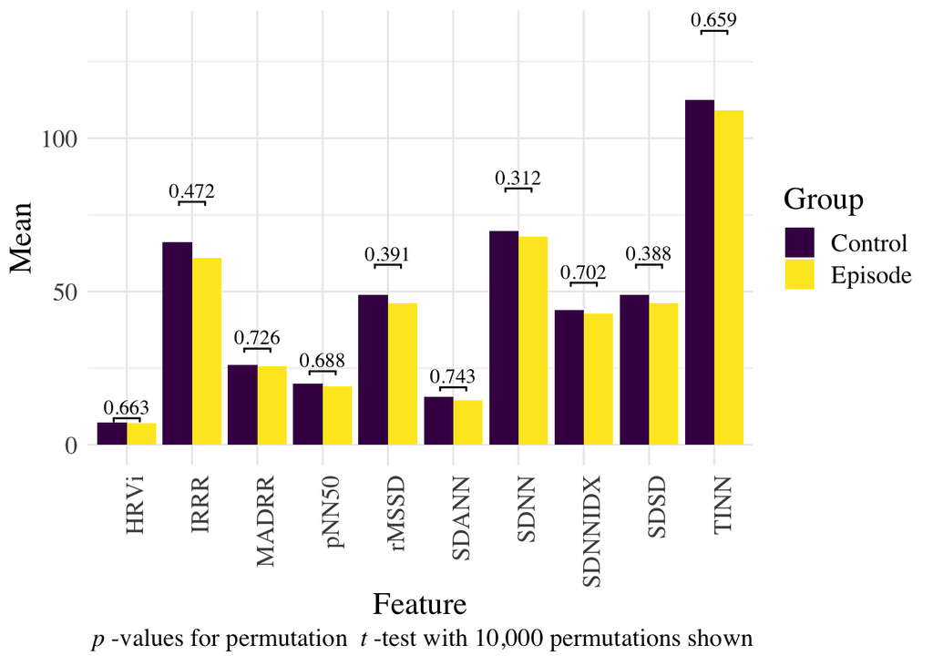

(ref:timeComparisonPlot)

```r
df_time_summaries %>%
  filter(str_detect(statistic, "control|episode|p.val")) %>%
  spread(key = statistic, value = value) %>%
  select(-p.val, everything()) %>%
  gather("Group", "Mean", mean.control:mean.episode) %>%
  permutation_plot(., tip = 0.01)+
    labs(caption = expression(~italic(p)~"-values for permutation "~italic(t)~"-test with 10,000 permutations shown"))
```

(ref:freqSummary) Summary of Features in the Frequency Domain

A similar approach was taken to analyze the frequency domain. Table @ref(tab:freqSummary) outlines the mean values of features.

```r
### tabulate the frequency domain means
order = c("Avg_HR", "Avg_niHR", "Start_niHR", "End_niHR",
          paste0("HF_", 1:6),
          paste0("LF_", 1:6),
          paste0("LFHF_", 1:6))
df_freq_summaries %>%
  filter(statistic != "p.val") %>%
  filter(!str_detect(statistic, "control|episode")) %>%
  spread(key = statistic, value = value) %>%
  select(variable, n, mean, sd) %>%
  slice(match(order, variable)) %>%
  kable(digits=2, caption = '(ref:freqSummary)') %>%
  kable_styling() %>%
  kableExtra::group_rows("Heart Rate", 1, 4) %>%
  kableExtra::group_rows("High Frequency", 5, 10) %>%
  kableExtra::group_rows("Low Frequency", 11, 16) %>%
  kableExtra::group_rows("LF-HF Ratio", 17, 22)
```

(ref:freqSummary)

| variable | n | mean | sd |
| --- | --- | --- | --- |
| **Heart Rate** |  |  |  |
| Avg_HR | 1497 | 79.50 | 12.13 |
| Avg_niHR | 1497 | 80.26 | 12.20 |
| Start_niHR | 1497 | 83.58 | 17.76 |
| End_niHR | 1497 | 81.34 | 15.69 |
| **High Frequency** |  |  |  |
| HF_1 | 515 | 282.34 | 382.80 |
| HF_2 | 528 | 271.35 | 351.14 |
| HF_3 | 535 | 262.68 | 291.35 |
| HF_4 | 522 | 248.05 | 289.56 |
| HF_5 | 511 | 254.59 | 317.44 |
| HF_6 | 515 | 295.68 | 432.77 |
| **Low Frequency** |  |  |  |
| LF_1 | 515 | 320.98 | 254.62 |
| LF_2 | 528 | 319.81 | 246.48 |
| LF_3 | 535 | 323.36 | 247.22 |
| LF_4 | 522 | 314.75 | 238.92 |
| LF_5 | 511 | 334.37 | 253.86 |
| LF_6 | 515 | 345.29 | 269.47 |
| **LF-HF Ratio** |  |  |  |
| LFHF_1 | 515 | 4.69 | 3.42 |
| LFHF_2 | 528 | 4.68 | 3.53 |
| LFHF_3 | 535 | 4.59 | 3.46 |
| LFHF_4 | 522 | 4.83 | 3.55 |
| LFHF_5 | 511 | 4.98 | 3.55 |
| LFHF_6 | 515 | 4.85 | 3.42 |

(ref:freqComparison) Between-Groups Permutation *t*-test of Frequency Domain Features

(ref:freqComparisonPlot) Between-Groups Permutation *t*-test of Frequency Domain Features: a) Heart Rate Features; b) High Frequency Features; c) Low Frequency Features d) Low Frequency-High Frequency Ratio Features

Using the same Two-*t* permutation approach, we found signficant differences in means for Average Heart Rate, Average non-interpolated Heart Rate, Ending non-interpolated Heart Rate, and the LF-HF ratio in the third window, shown in Table @ref(tab:freqComparison).

```r
### tabulate the results of the frequency domain permutation t test
df_freq_summaries %>%
  filter(str_detect(statistic, "control|episode|p.val")) %>%
  spread(key = statistic, value = value) %>%
  select(-p.val, everything()) %>%
  slice(match(order, variable)) %>%
  kable(digits=2, caption = '(ref:freqComparison)') %>%
  kable_styling() %>%
  kableExtra::group_rows("Heart Rate", 1, 4) %>%
  kableExtra::group_rows("High Frequency", 5, 10) %>%
  kableExtra::group_rows("Low Frequency", 11, 16) %>%
  kableExtra::group_rows("LF-HF Ratio", 17, 22)
```

(ref:freqComparison)

| variable | mean.control | mean.episode | n.control | n.episode | sd.control | sd.episode | p.val |
| --- | --- | --- | --- | --- | --- | --- | --- |
| **Heart Rate** |  |  |  |  |  |  |  |
| Avg_HR | 79.22 | 81.20 | 1282 | 215 | 12.25 | 11.30 | 0.03 |
| Avg_niHR | 80.01 | 81.76 | 1282 | 215 | 12.31 | 11.41 | 0.05 |
| Start_niHR | 83.56 | 83.70 | 1282 | 215 | 18.21 | 14.85 | 0.92 |
| End_niHR | 80.77 | 84.71 | 1282 | 215 | 15.55 | 16.12 | 0.00 |
| **High Frequency** |  |  |  |  |  |  |  |
| HF_1 | 272.59 | 333.79 | 433 | 82 | 329.02 | 591.06 | 0.18 |
| HF_2 | 263.68 | 316.23 | 451 | 77 | 305.91 | 546.34 | 0.22 |
| HF_3 | 257.48 | 292.74 | 456 | 79 | 257.94 | 438.11 | 0.31 |
| HF_4 | 244.61 | 266.51 | 440 | 82 | 259.52 | 416.97 | 0.55 |
| HF_5 | 262.25 | 202.95 | 445 | 66 | 335.09 | 143.31 | 0.14 |
| HF_6 | 305.57 | 233.80 | 444 | 71 | 460.86 | 163.01 | 0.18 |
| **Low Frequency** |  |  |  |  |  |  |  |
| LF_1 | 322.90 | 310.85 | 433 | 82 | 255.19 | 252.93 | 0.70 |
| LF_2 | 315.46 | 345.28 | 451 | 77 | 245.66 | 251.30 | 0.33 |
| LF_3 | 326.12 | 307.45 | 456 | 79 | 253.17 | 210.27 | 0.53 |
| LF_4 | 309.79 | 341.38 | 440 | 82 | 235.44 | 256.66 | 0.27 |
| LF_5 | 330.80 | 358.43 | 445 | 66 | 252.93 | 260.77 | 0.41 |
| LF_6 | 347.62 | 330.70 | 444 | 71 | 273.40 | 244.74 | 0.63 |
| **LF-HF Ratio** |  |  |  |  |  |  |  |
| LFHF_1 | 4.72 | 4.57 | 433 | 82 | 3.46 | 3.20 | 0.71 |
| LFHF_2 | 4.68 | 4.67 | 451 | 77 | 3.50 | 3.72 | 0.97 |
| LFHF_3 | 4.72 | 3.86 | 456 | 79 | 3.49 | 3.19 | 0.04 |
| LFHF_4 | 4.78 | 5.09 | 440 | 82 | 3.54 | 3.60 | 0.46 |
| LFHF_5 | 4.98 | 5.02 | 445 | 66 | 3.52 | 3.74 | 0.94 |
| LFHF_6 | 4.80 | 5.14 | 444 | 71 | 3.43 | 3.35 | 0.44 |

```r
faceted <- df_freq_summaries %>%
  filter(str_detect(statistic, "control|episode|p.val")) %>%
  spread(key = statistic, value = value) %>%
  select(-p.val, everything()) %>%
  gather("Group", "Mean", mean.control:mean.episode) %>%
  mutate(facet = case_when(
    str_detect(variable, "^HF_.*") ~ "High_Frequency",
    str_detect(variable, "^LF_.*") ~ "Low_Frequency",
    str_detect(variable, "^LFHF_.*") ~ "LF-HF Ratio",
    str_detect(variable, "HR") ~ "Heart Rate"
    )
  ) %>%
  nest(-facet)
plots <- pmap(list(df = faceted$data,
             height = c(1.1, 1.1, 1.1, 1.1),
             tip = c(0.3, 0.05, 0.1, 0.08)),
        permutation_plot)

#ggpubr::ggarrange(plotlist = plots, common.legend = T, font.label = list(face = 'bold', family = 'Times'), labels = paste0(letters[1:4], ")"))
```

(ref:freqComparisonPlotA) Between-Groups Permutation *t*-test of Frequency Domain Heart Rate Features

(ref:freqComparisonPlotB) Between-Groups Permutation *t*-test of High Frequency Features

(ref:freqComparisonPlotC) Between-Groups Permutation *t*-test of Low Frequency Features

(ref:freqComparisonPlotD) Between-Groups Permutation *t*-test of Low Frequency-High Frequency Ratio Features

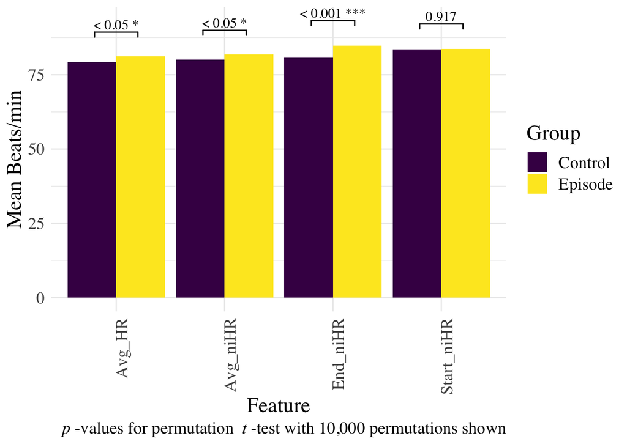

(ref:freqComparisonPlotA)

```r
## plot frequency domain significant vars (heart rate)
df_freq_summaries %>%
  filter(str_detect(statistic, "control|episode|p.val")) %>%
  spread(key = statistic, value = value) %>%
  select(-p.val, everything()) %>%
  gather("Group", "Mean", mean.control:mean.episode) %>%
  mutate(facet = case_when(
    str_detect(variable, "^HF_.*") ~ "High_Frequency",
    str_detect(variable, "^LF_.*") ~ "Low_Frequency",
    str_detect(variable, "^LFHF_.*") ~ "LF-HF Ratio",
    str_detect(variable, "HR") ~ "Heart Rate"
    )
  ) %>%
  filter(facet == "Heart Rate") %>%
  permutation_plot(., tip = 0.3, height = 1.1) +
      labs(caption = expression(~italic(p)~"-values for permutation "~italic(t)~"-test with 10,000 permutations shown")) +
  ylab(expression(paste("Mean Beats/min")))
```

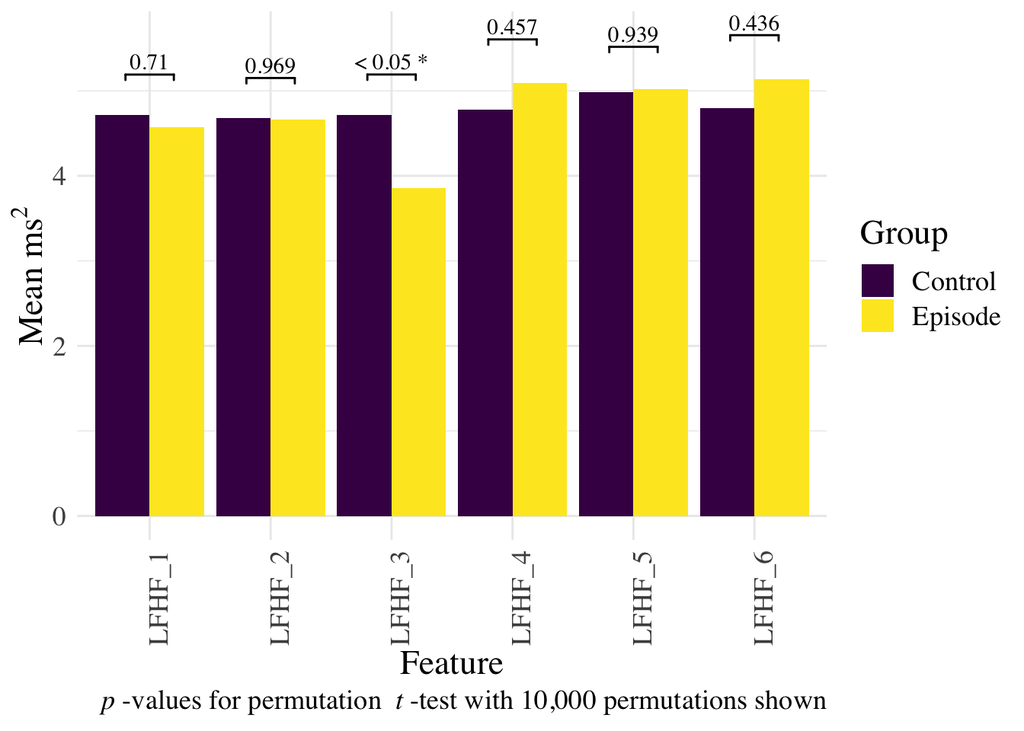

(ref:freqComparisonPlotD)

```r
## plot frequency domain significant vars (lfhf ratio)

df_freq_summaries %>%
  filter(str_detect(statistic, "control|episode|p.val")) %>%
  spread(key = statistic, value = value) %>%
  select(-p.val, everything()) %>%
  gather("Group", "Mean", mean.control:mean.episode) %>%
  mutate(facet = case_when(
    str_detect(variable, "^HF_.*") ~ "High_Frequency",
    str_detect(variable, "^LF_.*") ~ "Low_Frequency",
    str_detect(variable, "^LFHF_.*") ~ "LF-HF Ratio",
    str_detect(variable, "HR") ~ "Heart Rate"
    )
  ) %>%
  filter(facet == "LF-HF Ratio") %>%
  permutation_plot(., tip = 0.05, height = 1.1)+
      labs(caption = expression(~italic(p)~"-values for permutation "~italic(t)~"-test with 10,000 permutations shown")) +
  ylab(expression(paste("Mean ", ms^{2})))
```

## Machine Learning Analyses.

```r
### Define Functions for ML

### Main SVM model fitting function
modelfit <- function(data){

  train <- data$train
  test <- data$test
  # fit the model on the training set
  fit <- train(Y ~ ., data = train, method="svmPoly")

  # predict on the test set
  yhat = predict(fit, newdata = select(test, -Y))

  # evaluate test set accuracy
  conf <- caret::confusionMatrix(yhat, test$Y)
  result <- c(conf$overall[1], conf$byClass[1:2]) #<-can change threshold if you want
  result["auc"] <- auc(test$Y, yhat)

  return(result)

}

### Fit an SVM and perturb one column at a time
perturb_model_fit <- function(data){

  train <- data$train
  test <- data$test

  # fit the model on the training set
  invisible(capture.output(fit <- train(Y ~ ., data = train, method="svmPoly", trControl = trainControl(classProbs = TRUE))))
  # get these fitted probabilities
  y = predict(fit, newdata = select(test, -Y), type = "prob") %>%
    rownames_to_column()

  # perturb a column from the training set and get the new probabilities
  result <- list(Control = y)

  for(c in 2:ncol(test)){

    col <- names(train)[c]
    temp <- test
    temp[, col] <- temp[, col] + 1
    result[[col]] <- predict(fit, newdata = select(temp, -Y), type = "prob") %>%
      rownames_to_column()

  }

  # tidy the results before returning
  bound <- bind_rows(result, .id='Perturbed_Feature') %>%
    mutate(rowname = as.numeric(rowname)) %>%
    select(-Control) %>%
    spread(key = "Perturbed_Feature", value = Episode) %>%
    as_tibble() %>%
    bind_cols(Y = test$Y)

  return(bound)

}

### Split a dataset into a train and test set
train_test <- function(dataset, folder, print = FALSE){

  # issue here with namespace and "data" variable reference
  data <- dataset[-folder, ]
  mytest <- dataset[folder, ]

  # generate a balanced training set
  train <- ovun.sample(
    Y ~ .,
    data=data,
    method = "both",
    p = 0.6,
    seed = 1342
  )$data

  train <- as_tibble(train) %>%
    droplevels()
  test <- as_tibble(mytest) %>%
    droplevels()

  if(print){
    print("Training set:")
    print(train)
    print(table(train$Y))
    print("Testing set:")
    print(test)
    print(table(test$Y))
  }

  return(list(train = train, test = test))

}

### Get variable importance by looping over the columns, leave-one-out for each model; uses main model fitting function
leave_one_out_auc <- function(df, col){

  df_reduced <- df %>%
    select(-!!col)      # remove this column
  set.seed(9)
  nfolds <- 4
  subdata <- createFolds(df_reduced$Y, nfolds)

  temp1 <- train_test(df_reduced, subdata$Fold1) %>%
    modelfit()
  temp2 <- train_test(df_reduced, subdata$Fold2) %>%
    modelfit()
  temp3 <- train_test(df_reduced, subdata$Fold3) %>%
    modelfit()
  temp4 <- train_test(df_reduced, subdata$Fold4)%>%
    modelfit()


  auc <- colMeans(rbind(temp1['auc'],temp2['auc'], temp3['auc'], temp4['auc'])) %>%
    t() %>%
    data.frame(auc = ., variable = names(df)[col])
  return(auc)
}
```

```r
# prep datasets

df_time_ml <- read.csv(here('data', 'Preprocessing_data_outputs', 'Paper', 'data_out.csv'))%>%
  # use params threshold = 250, windows = 2
  filter(threshold == 250 & winds == 2)%>%
  select(-winds, - threshold, -index) %>%
  filter(complete.cases(.)) %>%
  filter(!((Stress>=5) & (Y == "Control")))

df_time_ml <- df_time_ml %>%
  mutate(ID = as.factor(ID)) %>%
  group_by(ID) %>%
  mutate_at(vars(SDNN:HRVi), scale) %>%
  ungroup() %>%
  select(Y:HRVi) %>%
  filter(complete.cases(.))

df_freq_ml <- read.csv(here('data', 'Preprocessing_data_outputs', 'Paper', 'data_out_20181113.csv'))%>%
  # use params threshold = 250, windows = 2
  select(-c(winds, threshold, index, when, Event)) %>%
  select(Y, ID, Stress, Avg_niHR:LF_6) %>%
  filter(complete.cases(.)) %>%
  filter(!(Stress >= 5 & Y == "Control"))


df_freq_ml <- df_freq_ml %>%
  mutate(ID = as.factor(ID)) %>%
  group_by(ID) %>%
  mutate_at(vars(Avg_niHR:LF_6), scale) %>%
  ungroup() %>%
  select(Y, Avg_niHR:LF_6) %>%
  filter(complete.cases(.))
```

```r
### Run time domain ML
set.seed(9)
nfolds <- 4
subdata<-createFolds(df_time_ml$Y, nfolds)
t1_z <- train_test(df_time_ml, subdata$Fold1) %>%
  modelfit()
t2_z <- train_test(df_time_ml, subdata$Fold2) %>%
  modelfit()
t3_z <- train_test(df_time_ml, subdata$Fold3) %>%
  modelfit()
t4_z <- train_test(df_time_ml, subdata$Fold4) %>%
  modelfit()
results_time <- colMeans(rbind(t1_z, t2_z, t3_z, t4_z))
```

```r
### Compute time domain AUC comparison

auc_comparison_time <- list()

for(c in 2:ncol(df_time_ml)){
  auc_comparison_time <- leave_one_out_auc(df_time_ml, c) %>%
    rbind(auc_comparison_time)
}

auc_time <- auc_comparison_time %>%
  mutate(Reduction_AUC = results_time['auc'] - auc) %>%
  mutate(Reduction_AUC = rescale(Reduction_AUC, c(0,1))) %>%
  arrange(-Reduction_AUC)
```

```r
### Compute time domain perturbation comparison

set.seed(9)
nfolds <- 4
subdata<-createFolds(df_time_ml$Y, nfolds)

perturbed_time_1 <- train_test(df_time_ml, subdata$Fold1) %>%     # split train and test
  perturb_model_fit() %>%                                   # fit model and perturb each column
  mutate_at(                                                # tidy to get differences
    .vars = vars(-rowname, -Y, -Control),
    .funs = list(Delta = ~. - Control))# %>%
  #select(Y, contains("Delta"))

perturbed_time_2 <- train_test(df_time_ml, subdata$Fold2) %>%     # split train and test
  perturb_model_fit() %>%                                   # fit model and perturb each column
  mutate_at(                                                # tidy to get differences
    .vars = vars(-rowname, -Y, -Control),
    .funs = list(Delta = ~. - Control)) #%>%
  #select(Y, contains("Delta"))

perturbed_time_3 <- train_test(df_time_ml, subdata$Fold3) %>%     # split train and test
  perturb_model_fit() %>%                                   # fit model and perturb each column
  mutate_at(                                                # tidy to get differences
    .vars = vars(-rowname, -Y, -Control),
    .funs = list(Delta = ~. - Control)) #%>%
  #select(Y, contains("Delta"))

perturbed_time_4 <- train_test(df_time_ml, subdata$Fold4) %>%     # split train and test
  perturb_model_fit() %>%                                   # fit model and perturb each column
  mutate_at(                                                # tidy to get differences
    .vars = vars(-rowname, -Y, -Control),
    .funs = list(Delta = ~. - Control)) #%>%
  #select(Y, contains("Delta"))
```

```r
### ML frequency domain

set.seed(9)
nfolds <- 4
subdata<-createFolds(df_freq_ml$Y, nfolds)
f1_z <- train_test(df_freq_ml, subdata$Fold1) %>%
  modelfit()
f2_z <- train_test(df_freq_ml, subdata$Fold2) %>%
  modelfit()
f3_z <- train_test(df_freq_ml, subdata$Fold3) %>%
  modelfit()
f4_z <- train_test(df_freq_ml, subdata$Fold4) %>%
  modelfit()
results_freq <- colMeans(rbind(f1_z, f2_z, f3_z, f4_z))
```

```r
### frequency domain AUC comparison

auc_comparison_freq <- list()

for(c in 2:ncol(df_freq_ml)){
  auc_comparison_freq <- leave_one_out_auc(df_freq_ml, c) %>%
    rbind(auc_comparison_freq)
}

auc_freq <- auc_comparison_freq %>%
  mutate(Reduction_AUC = results_freq['auc'] - auc) %>%
  mutate(Reduction_AUC = rescale(Reduction_AUC, c(0,1))) %>%
  arrange(-Reduction_AUC)
```

```r
### frequency domain perturbation comparison

set.seed(9)
nfolds <- 4
subdata<-createFolds(df_freq_ml$Y, nfolds)

perturbed_freq_1 <- train_test(df_freq_ml, subdata$Fold1) %>%     # split train and test
  perturb_model_fit() %>%                                   # fit model and perturb each column
  mutate_at(                                                # tidy to get differences
    .vars = vars(-rowname, -Y, -Control),
    .funs = list(Delta = ~. - Control)) #%>%
  #select(Y, contains("Delta"))

perturbed_freq_2 <- train_test(df_freq_ml, subdata$Fold2) %>%     # split train and test
  perturb_model_fit() %>%                                   # fit model and perturb each column
  mutate_at(                                                # tidy to get differences
    .vars = vars(-rowname, -Y, -Control),
    .funs = list(Delta = ~. - Control)) #%>%
  #select(Y, contains("Delta"))

perturbed_freq_3 <- train_test(df_freq_ml, subdata$Fold3) %>%     # split train and test
  perturb_model_fit() %>%                                   # fit model and perturb each column
  mutate_at(                                                # tidy to get differences
    .vars = vars(-rowname, -Y, -Control),
    .funs = list(Delta = ~. - Control)) #%>%
  #select(Y, contains("Delta"))

perturbed_freq_4 <- train_test(df_freq_ml, subdata$Fold4) %>%     # split train and test
  perturb_model_fit() %>%                                   # fit model and perturb each column
  mutate_at(                                                # tidy to get differences
    .vars = vars(-rowname, -Y, -Control),
    .funs = list(Delta = ~. - Control)) #%>%
  #select(Y, contains("Delta"))
```

```r
## data munging to collate the results
time_domain_deltas <- bind_rows(perturbed_time_1, perturbed_time_2, perturbed_time_3, perturbed_time_4) %>%
  summarise_if(is.numeric, mean) %>%
  select(-rowname) %>%
  t() %>%
  as.data.frame() %>%
  rownames_to_column("variable") %>%
  filter(str_detect(variable, "Delta")) %>%
  transmute(variable = str_remove(variable, "_Delta"), Delta_Probability = V1)

freq_domain_deltas <- bind_rows(perturbed_freq_1, perturbed_freq_2, perturbed_freq_3, perturbed_freq_4) %>%
  summarise_if(is.numeric, mean) %>%
  select(-rowname) %>%
  t() %>%
  as.data.frame() %>%
  rownames_to_column("variable") %>%
  filter(str_detect(variable, "Delta")) %>%
  transmute(variable = str_remove(variable, "_Delta"), Delta_Probability = V1)
```

(ref:ml-metrics) Machine Learning Evaluation Metrics

Machine learning models were implemented using time domain and frequency domain features separately. In order to run machine learning prediction of emotional eating episodes, only observations with complete data for all features in the time or frequency domain were used, data within each participant were scaled and centered, and observations were randomly upsampled (from episodes) or downsampled (from controls) to balance the number of observations and controls. SVM models were fit iteratively using 3/4’s of the data, and evaluated on the remaining 1/4. Figure @ref(fig:ml-metrics) shows the mean accuracy, sensitivity, and specificity of the SVM across these four folds.

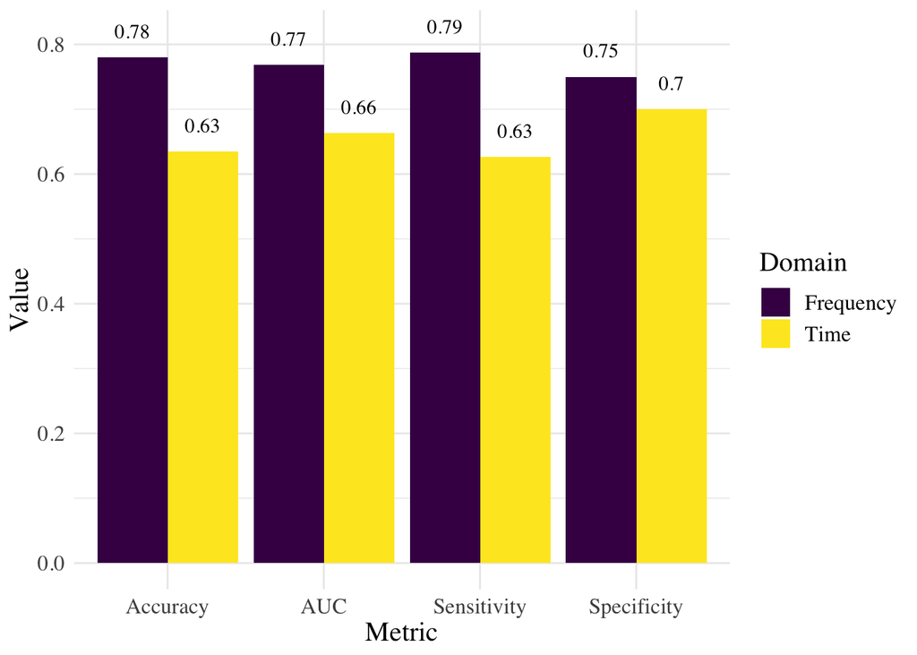

(ref:ml-metrics)

```r
### plotting the ml results
ml_time <- results_time %>%
  enframe(name = "Metric", value = "Value") %>%
  mutate(Metric = ifelse(Metric == "auc", "AUC", Metric),
         Domain = "Time")

ml_freq <- results_freq %>%
  enframe(name = "Metric", value = "Value") %>%
  mutate(Metric = ifelse(Metric == "auc", "AUC", Metric),
         Domain = "Frequency")

bind_rows(ml_time, ml_freq) %>%
  ggplot(aes(x=Metric, y=Value, fill=Domain))+
  geom_col(position = "dodge") +
  geom_text(aes(label=formatC(Value, 2), y = Value + 0.025), position = position_dodge(width=0.9), vjust=-0.25, family = "Times") +
  theme_minimal() +
  scale_fill_viridis_d() +
  theme(text = element_text(size=15, family = "Times"))
```

(ref:varImportance-time) Pseudo-Feature Importance by Removing & Perturbing Each Feature: Time Domain

(ref:varImportance-freq) Pseudo-Feature Importance by Removing & Perturbing Each Feature: Frequency Domain

To interpret the feature importance in each of these models, ROC curve analysis was conducted on each feature on the model as recommended by Khun Jed Wing et al. (2018), by systemmatically removing each variable from the model and comparing the achieved Area Under the Curve (AUC) against that of the full model. In order to assess whether or not these features discriminate well between episodes and controls, models were fitted on the original data and the fitted values were perturbed for each variable. The probabilities of predictions were extracted from each perturbed model and compared to the probabilities of the original model, to understand how increasing values of the features increased or decreased the likelihood of an eating episode. Figures @ref(fig:varImportance-time) and @ref(fig:varImportance-freq) show the results of this analysis.

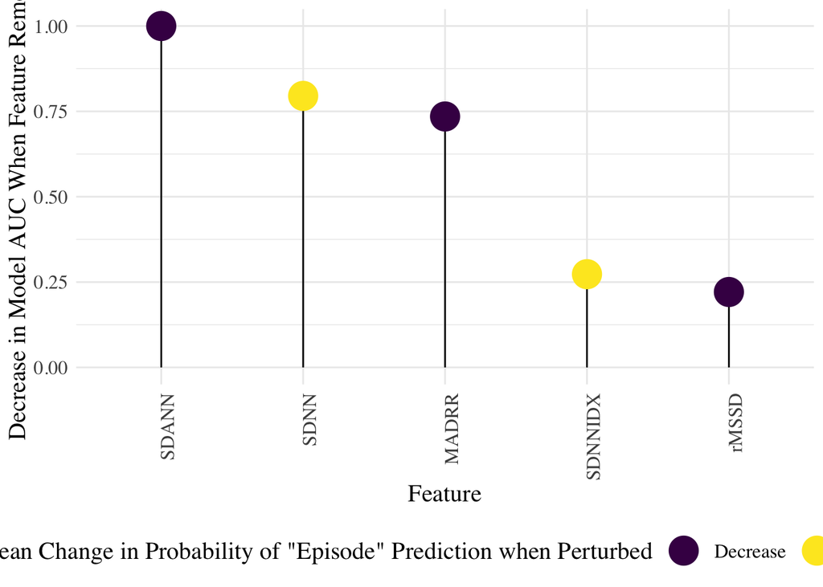

(ref:varImportance-time)

```r
## plotting the time domain variable importance
time_domain_deltas %>%
  #group_by(variable) %>%
  #summarise(Delta_Probability = mean(Delta_Probability)) %>%
  right_join(auc_time, by = "variable") %>%
  as_tibble() %>%
  mutate(
    Feature = fct_reorder(variable, Reduction_AUC, .desc = TRUE),
    Delta_Probability = as.factor(ifelse(Delta_Probability >= 0, "Increase", "Decrease"))
  ) %>%
  filter(Reduction_AUC > 0.2 & variable != "SDSD") %>%
  select(-variable) %>%
  ggplot(aes(x = Feature, y = Reduction_AUC))+
    geom_segment(
      aes(
        y = 0,
        x = Feature,
        yend = Reduction_AUC,
        xend = Feature
      ),
      color = "black"
    ) +
    geom_point(aes(colour = Delta_Probability), size = 8) +
    theme_minimal() +
    theme(
      axis.text.x = element_text(angle = 90, hjust = 1),
      text = element_text(size=15, family = "Times"),
      legend.position = "bottom"
    ) +
    labs(
      x = "Feature",
      y = "Decrease in Model AUC When Feature Removed"
    ) +
  scale_color_viridis_d(name = "Mean Change in Probability of \"Episode\" Prediction when Perturbed")
```

In the time domain, the most important feature by measure of scaled decrease in model AUC was *SDANN*, followed by *SDNN* and *MADRR*. Increasing values in *SDANN* by 1 unit tended to decrease the probability of observations being predicted as episode, suggesting that higher levels of *SDANN* decrease the likelihood of an eating episode. This same inference can be made of *MADRR*. In the case of *SDNN*, a 1 unit increase in values of this feature increased the probability of observations being predicted as episodes.

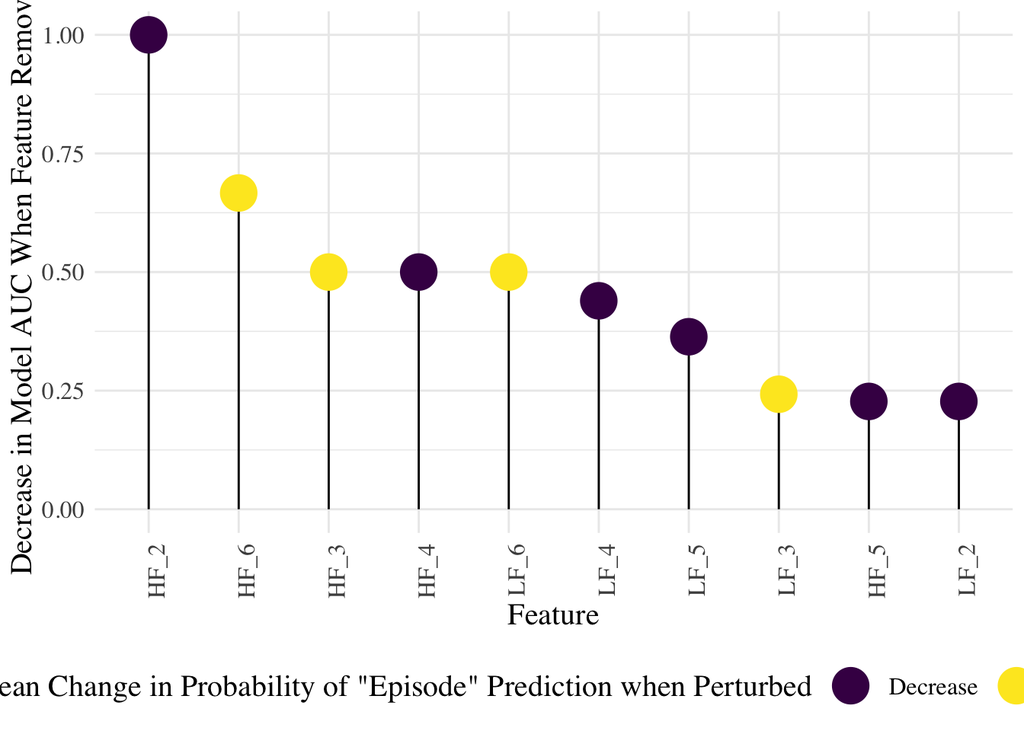

(ref:varImportance-freq)

```r
## plotting the frequency domain variable importance

freq_domain_deltas %>%
  #group_by(variable) %>%
  #summarise(Delta_Probability = mean(Delta_Probability)) %>%
  right_join(auc_freq, by = "variable") %>%
  as_tibble() %>%
  mutate(
    Feature = fct_reorder(variable, Reduction_AUC, .desc = TRUE),
    Delta_Probability = as.factor(ifelse(Delta_Probability >= 0, "Increase", "Decrease"))
  ) %>%
  filter(Reduction_AUC > 0.2) %>%
  select(-variable) %>%
  ggplot(aes(x = Feature, y = Reduction_AUC))+
    geom_segment(
      aes(
        y = 0,
        x = Feature,
        yend = Reduction_AUC,
        xend = Feature
      ),
      color = "black"
    ) +
    geom_point(aes(colour = Delta_Probability), size = 8) +
    theme_minimal() +
    theme(
      axis.text.x = element_text(angle = 90, hjust = 1),
      text = element_text(size=15, family = "Times"),
      legend.position = "bottom"
    ) +
    #facet_grid(Y~.) +
    labs(
      x = "Feature",
      y = "Decrease in Model AUC When Feature Removed"
    ) +
  scale_color_viridis_d(name = "Mean Change in Probability of \"Episode\" Prediction when Perturbed")
```

In the frequency domain, the most important features by measure of decrease in model AUC were the High Frequency windows $HF_2$, $HF_6$, and $HF_3$. Increasing values in $HF_2$ by one unit tended to decrease the probability of observations being predicted as episode, suggesting that stronger signals in the high frequency band at this time in the window decrease the likelihood of an eating episode. This inference is the opposite, however, for $HF_6$ and $HF_3$, which show that increasing these variables’ values by one unit tends to increase the likelihood of an eating episode. Interestingly, while the heart rate variables *Avg_HR*, *Avg_niHR*, and *End_niHR* had significantly different means, their affect on the achieved AUC was relatively minimal, indicating they had very small feature importance for this model.

(ref:highfreq-timeseries) Time Series of High Frequency Band

(ref:lowfreq-timeseries) Time Series of Low Frequency Band

To better interpret how the signal in the high frequency band of heart rate varies through the 30-minute window, we plot these values in Figure @ref(fig:highfreq-timeseries).

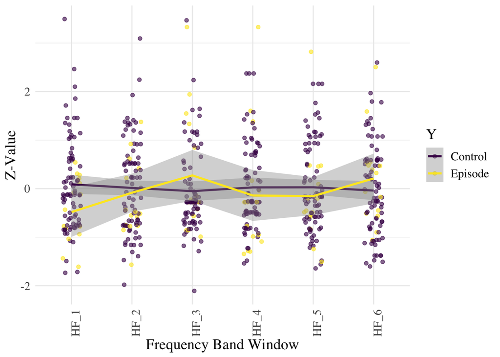

(ref:highfreq-timeseries)

```r
## plot the raw data for clarity

df_freq_ml %>%
  gather('variable', 'value', HF_1:HF_6) %>%
  #mutate(facet = ifelse(str_detect(variable, 'HF'), "HF", "LF")) %>%
  ggplot(aes(x=variable, y=value, colour=Y)) +
    geom_jitter(alpha = 0.6, width = 0.15) +
    stat_smooth(aes(group = Y), method = "loess") +
    #facet_wrap(facet~.) +
    labs(x = "Frequency Band Window", y = "Z-Value") +
    theme_minimal() +
    theme(
        axis.text.x = element_text(angle = 90, hjust = 1),
        text = element_text(size=15, family = "Times")
    ) +
    scale_color_viridis_d()
```

The visualisation shows that at the second window, $HF_2$, there is an inverse relationship between the trajectories of episodes and controls, which may represent the high variable importance of $HF_2$. $HF_6$ shows a similar inverse trend, as increasing values of this variable are associated with episodes while decreasing values are associated with controls.

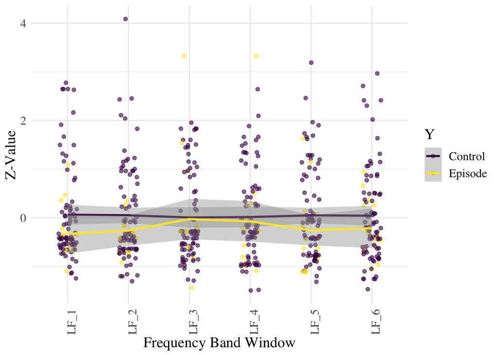

(ref:lowfreq-timeseries)

```r
## plot the raw data for clarity

df_freq_ml %>%
  gather('variable', 'value', LF_1:LF_6) %>%
  #mutate(facet = ifelse(str_detect(variable, 'HF'), "HF", "LF")) %>%
  ggplot(aes(x=variable, y=value, colour=Y)) +
    geom_jitter(alpha = 0.6, width = 0.15) +
    stat_smooth(aes(group = Y), method = "loess") +
    #facet_wrap(facet~.) +
    labs(x = "Frequency Band Window", y = "Z-Value") +
    theme_minimal() +
    theme(
        axis.text.x = element_text(angle = 90, hjust = 1),
        text = element_text(size=15, family = "Times")
    ) +
    scale_color_viridis_d()
```

(ref:corrplot-time) Correlation Matrix of Time Domain Features

Additionally, a correlation matrix is added to address how features may interact in Figures @ref(fig:corrplot-time) and @ref(fig:corrplot-freq).

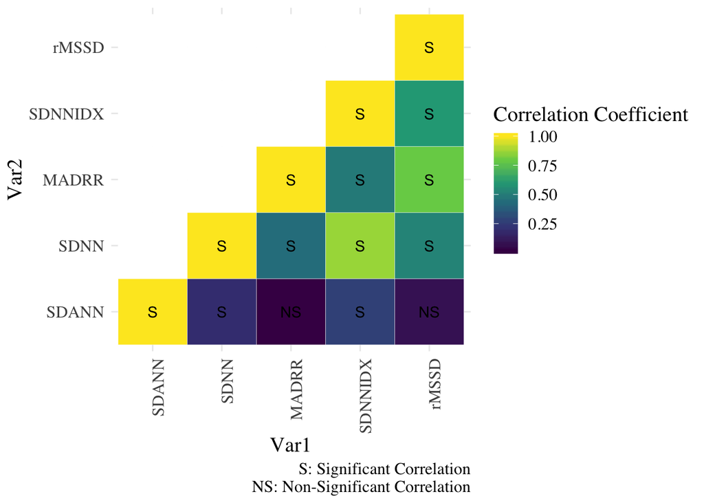

(ref:corrplot-time)

```r
time_features <- time_domain_deltas %>%
  #group_by(variable) %>%
  #summarise(Delta_Probability = mean(Delta_Probability)) %>%
  right_join(auc_time, by = "variable") %>%
  as_tibble() %>%
  mutate(
    Feature = fct_reorder(variable, Reduction_AUC, .desc = TRUE),
    Delta_Probability = as.factor(ifelse(Delta_Probability >= 0, "Increase", "Decrease"))
  ) %>%
  filter(Reduction_AUC > 0.2 & variable != "SDSD") %>%
  select(variable) %>%
  pull()

p_mat <- df_time_ml %>%
  select(time_features) %>%
  cor_pmat() %>%
  as_tibble(rownames = 'id') %>%
  mutate_at(vars(-id), funs(case_when(. >= 0.05 ~ "NS", . < 0.05 ~ "S"))) %>%
  column_to_rownames('id') %>%
  as.matrix() %>%
  {
    .[upper.tri(.)] <- NA
    .
  } %>%
  reshape2::melt(value.name = "p_val")

df_time_ml %>%
  select(time_features) %>%
  cor() %>%
  round(3) %>%
  {
    .[upper.tri(.)] <- NA
    .
  } %>%
  reshape2::melt() %>%
  left_join(p_mat) %>%
  #ggcorrplot(type = 'lower', outline.color = "white") +
  ggplot(aes(Var1, Var2, fill = value)) +
  geom_tile(color = "white") +
  geom_text(aes(label = p_val)) +
  scale_fill_viridis_c(name = "Correlation Coefficient", na.value = 'white') +
  theme_minimal() +
  theme(
    text = element_text(size=15, family = "Times"),
    axis.text.x = element_text(angle = 90, hjust = 1)
    ) +
  labs(caption = "S: Significant Correlation\nNS: Non-Significant Correlation")
```

```r
  NULL
```

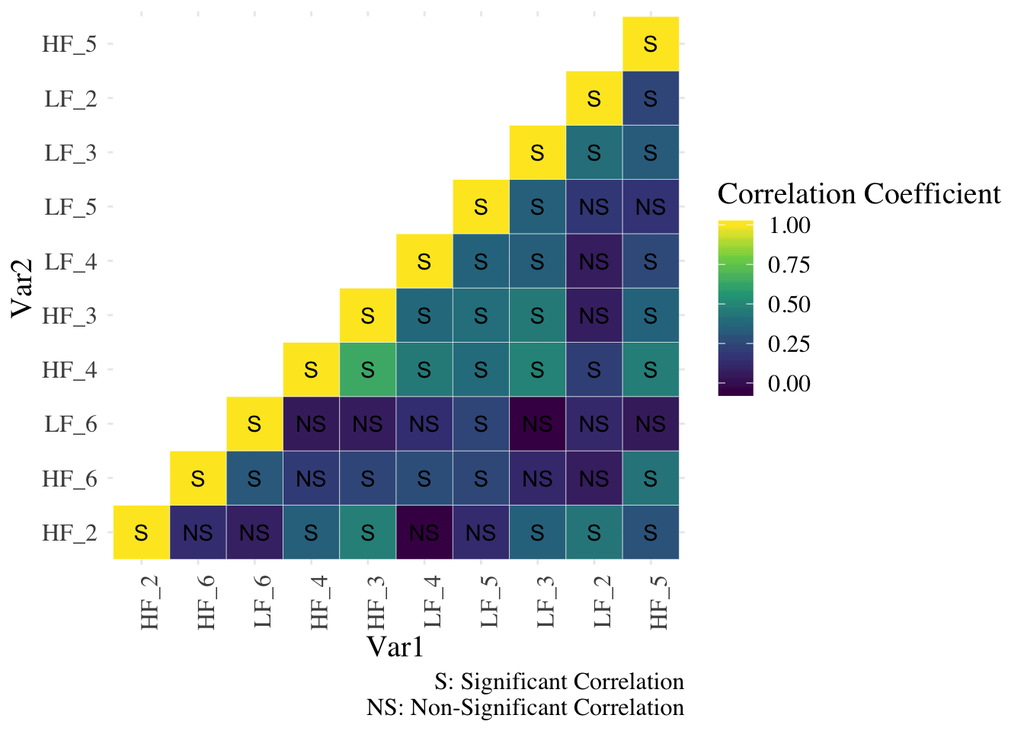

```r
frequency_features <- freq_domain_deltas %>%
  #group_by(variable) %>%
  #summarise(Delta_Probability = mean(Delta_Probability)) %>%
  right_join(auc_freq, by = "variable") %>%
  as_tibble() %>%
  mutate(
    Feature = fct_reorder(variable, Reduction_AUC, .desc = TRUE),
    Delta_Probability = as.factor(ifelse(Delta_Probability >= 0, "Increase", "Decrease"))
  ) %>%
  filter(Reduction_AUC > 0.2) %>%
  select(variable) %>%
  pull()

p_mat <- df_freq_ml %>%
  select(frequency_features) %>%
  cor_pmat() %>%
  as_tibble(rownames = 'id') %>%
  mutate_at(vars(-id), funs(case_when(. >= 0.05 ~ "NS", . < 0.05 ~ "S"))) %>%
  column_to_rownames('id') %>%
  as.matrix() %>%
  {
    .[upper.tri(.)] <- NA
    .
  } %>%
  reshape2::melt(value.name = "p_val")


df_freq_ml %>%
  select(frequency_features) %>%
  cor() %>%
    round(3) %>%
  {
    .[upper.tri(.)] <- NA
    .
  } %>%
  reshape2::melt() %>%
  left_join(p_mat) %>%
  #ggcorrplot(type = 'lower', outline.color = "white") +
  ggplot(aes(Var1, Var2, fill = value)) +
  geom_tile(color = "white") +
  geom_text(aes(label = p_val)) +
  scale_fill_viridis_c(name = "Correlation Coefficient", na.value = 'white') +
  theme_minimal() +
  theme(
    text = element_text(size=15, family = "Times"),
    axis.text.x = element_text(angle = 90, hjust = 1)
    ) +
  labs(caption = "S: Significant Correlation\nNS: Non-Significant Correlation")
```

```r
  NULL
```

# Discussion

A major hurdle to producing interpretable results is the sanity of data obtained from the devices. Despite best efforts, figures @ref(fig:missingness-time) and @ref(fig:missingness-freq) illustrate how sparse the data can be and how this affects its overall usefulness in running analyses.The causes for this data sparsity are unclear, and could include reasons such as improper usage or low signal while recording data. The result of this challenge is that derived features are incalculable; for example, time domain feature calculations are strongly dependent on a sliding window that must have within it at least some number of consecutive heart beats, or completeness and consecutiveness of *SDNN*; frequency domain variables are dependent on Fourier transforms which are sensitive to small and variations in wave frequencies. Nevertheless, by following proper data sanity checks and procedures provided in analyses packages and in the literature, it’s still possible to extract useful information from these data.

Friesen, C. A., Z. Lin, J. V. Schurman, L. Andre, and R. W. Mc Callum. 2007. “Autonomic Nervous System Response to a Solid Meal and Water Loading in Healthy Children: Its Relation to Gastric Myoelectrical Activity.” *Neurogastroenterology & Motility* 19 (5): 376–82. https://doi.org/10.1111/j.1365-2982.2007.00906.x.

Good, Phillip. 2013. *Permutation Tests: A Practical Guide to Resampling Methods for Testing Hypotheses*. Springer Science & Business Media.

Harthoorn, Lucien F., and Eric Dransfield. 2007. “Periprandial Changes of the Sympathetic–Parasympathetic Balance Related to Perceived Satiety in Humans.” *European Journal of Applied Physiology* 102 (5): 601–8. https://doi.org/10.1007/s00421-007-0622-5.

Jed Wing, Max Kuhn. Contributions from, Steve Weston, Andre Williams, Chris Keefer, Allan Engelhardt, Tony Cooper, Zachary Mayer, et al. 2018. *Caret: Classification and Regression Training*. https://CRAN.R-project.org/package=caret.

Lunardon, Nicola, Giovanna Menardi, and Nicola Torelli. 2014. *ROSE: Random over-Sampling Examples*. https://CRAN.R-project.org/package=ROSE.

Maindonald, John H., and W. John Braun. 2015. *DAAG: Data Analysis and Graphics Data and Functions*. https://CRAN.R-project.org/package=DAAG.

Ranzenhofer, Lisa M, Scott G Engel, Ross D Crosby, Mark Haigney, Micheline Anderson, Jeanne M McCaffery, and Marian Tanofsky-Kraff. 2016. “Real-Time Assessment of Heart Rate Variability and Loss of Control Eating in Adolescent Girls: A Pilot Study.” *International Journal of Eating Disorders* 49 (2): 197–201.

Rodriguez-Linares, Leandro, Xose Vila, Maria Jose Lado, Arturo Mendez, Abraham Otero, and Constantino Antonio Garcia. 2017. *RHRV: Heart Rate Variability Analysis of Ecg Data*. https://CRAN.R-project.org/package=RHRV.

Rubin, Jonathan, Rui Abreu, Shane Ahern, Hoda Eldardiry, and Daniel G. Bobrow. 2016. “Time, Frequency &#38; Complexity Analysis for Recognizing Panic States from Physiologic Time-Series.” In *Proceedings of the 10th Eai International Conference on Pervasive Computing Technologies for Healthcare*, 81–88. PervasiveHealth ’16. ICST, Brussels, Belgium, Belgium: ICST (Institute for Computer Sciences, Social-Informatics; Telecommunications Engineering). http://dl.acm.org/citation.cfm?id=3021319.3021332.

Shaffer, Fred, and J. P. Ginsberg. 2017. “An Overview of Heart Rate Variability Metrics and Norms.” *Frontiers in Public Health* 5. https://doi.org/10.3389/fpubh.2017.00258.